# 432 Class 16

Thomas E. Love, Ph.D.

2025-03-06

## Today’s Agenda

- Testing the difference between two survival curves
  - log rank tests (Mantel-Haenszel)
  - Peto-Peto modification of the Gehan-Wilcoxon test
- Customizing a Kaplan-Meier plot
  - Plotting Cumulative Event Rates and Cumulative Hazards
- A larger example: Colon Cancer Trial
  - Survival Objects and Kaplan-Meier Estimates
  - Fitting a simple Cox Regression model

## Today’s R Setup

```r
knitr::opts_chunk$set(comment = NA)

library(janitor)
library(naniar)
library(conflicted)
library(here)
library(survival)
library(survminer)
library(easystats)
library(tidyverse)

theme_set(theme_bw())
conflicts_prefer(dplyr::filter)
```

# Our Original Example (from Class 15)

## The `aml_432` data

The `aml` data provided in the **survival** package describe survival times (in months) for 23 subjects with acute myelogenous leukemia.

Question: Should the standard course of chemotherapy be extended (maintained) for additional cycles or not?

```r
aml_432 <- survival::aml |> tibble() |>
  rename(maintain = x, censored = status, months = time) |>
  arrange(desc(months)) |>
  mutate(subject = as.character(row_number()),
         death = 1 - censored,
         maintain =
           fct_recode(maintain, "Main" = "Maintained",
                      "No" = "Nonmaintained")) |>
  relocate(subject)
```

## The `aml_432` codebook

| `aml_432` | Description |
| --- | --- |
| `subject` | subject identifying code |
| `months` | known months of survival in follow-up period |
| `censored` | 1 if subject’s follow-up was censored, else 0 |
| `maintain` | Chemotherapy was Maintained (Main or No) |
| `death` | 1-`censored`, so 1 if died, 0 if censored. |

## Survival Object and K-M Estimator by Maintenance Group

```r
surv_aml <- Surv(time = aml_432$months, event = aml_432$death)

km_aml_grp <- survfit(surv_aml ~ aml_432$maintain)
print(km_aml_grp, print.rmean = TRUE)
```

```
Call: survfit(formula = surv_aml ~ aml_432$maintain)

                       n events rmean* se(rmean) median 0.95LCL 0.95UCL
aml_432$maintain=Main 11      4   97.2      28.4    103      28      NA
aml_432$maintain=No   12      1  140.3      19.2     NA      NA      NA
    * restricted mean with upper limit =  161
```

## Kaplan-Meier Plot, by Group

```r
ggsurvplot(km_aml_grp, data = aml_432,
           ggtheme = theme_bw(), palette = "lancet",
           conf.int = TRUE,
           xlab = "Time in months",
           break.time.by = 12,
           risk.table = TRUE,
           risk.table.height = 0.25,
           risk.table.col = "strata",
           pval = TRUE)
```

## Kaplan-Meier Plot, by Group

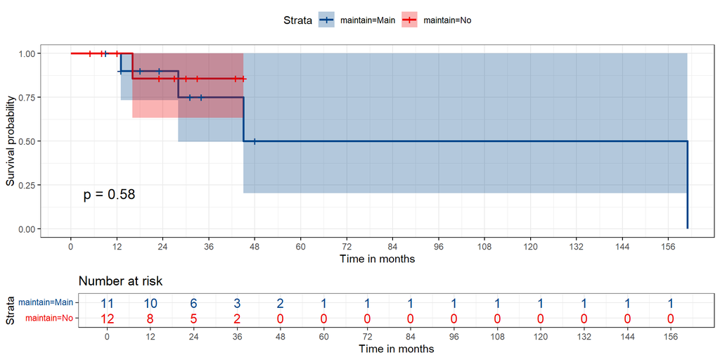

## Testing the difference between 2 survival curves

To obtain a significance test comparing these two survival curves, we turn to a log rank test, which tests the null hypothesis $H_0: S_1(t) = S_2(t)$ for all $t$ where the two exposures have survival functions $S_1(t)$ and $S_2(t)$.

```r
survdiff(surv_aml ~ aml_432$maintain)
```

```
Call:
survdiff(formula = surv_aml ~ aml_432$maintain)

                       N Observed Expected (O-E)^2/E (O-E)^2/V
aml_432$maintain=Main 11        4     3.47    0.0804     0.304
aml_432$maintain=No   12        1     1.53    0.1827     0.304

 Chisq= 0.3  on 1 degrees of freedom, p= 0.6
```

## Alternative log rank tests

An alternative is the *Peto and Peto modification of the Gehan-Wilcoxon test*, which results from adding `rho=1` to the `survdiff` function (`rho=0`, the default, yields the log rank test.)

```r
survdiff(surv_aml ~ aml_432$maintain, rho = 1)
```

```
Call:
survdiff(formula = surv_aml ~ aml_432$maintain, rho = 1)

                       N Observed Expected (O-E)^2/E (O-E)^2/V
aml_432$maintain=Main 11    3.262      2.8    0.0751     0.275
aml_432$maintain=No   12    0.941      1.4    0.1504     0.275

 Chisq= 0.3  on 1 degrees of freedom, p= 0.6
```

## Alternative log rank tests

- As compared to the log rank test, this Peto-Peto modification (and others using `rho > 0`) give greater weight to the left hand (earlier) side of the survival curves.
- To obtain chi-square tests that give greater weight to the right hand (later) side of the survival curves than the log rank test, use `rho < 0`.

The log rank test generalizes to permit survival comparisons across more than two groups.

## A Highly Customized K-M Plot

```r
ggsurvplot(km_aml_grp,
           data = aml_432,
           palette = c("red", "blue"),
           risk.table = TRUE,
           pval = TRUE,
           conf.int = TRUE,
           xlab = "Time in months",
           break.time.by = 6,
           ggtheme = theme_bw(),
           risk.table.y.text.col = T,
           risk.table.height = 0.25,
           risk.table.y.text = FALSE,
           ncensor.plot = TRUE,
           ncensor.plot.title = "Censoring counts",
           ncensor.plot.height = 0.25,
           conf.int.style = "step",
           surv.median.line = "hv")
```

## A Highly Customized K-M Plot

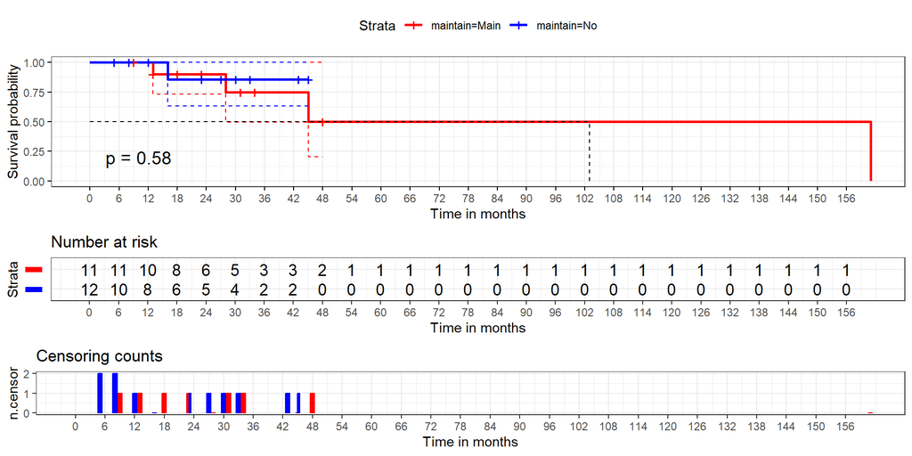

## Customizing the K-M Plot Further

See https://rpkgs.datanovia.com/survminer/ or https://github.com/kassambara/survminer/ for many more options.

Also, consider [this YouTube Video from Frank Harrell](https://www.youtube.com/watch?v=EoIB_Obddrk) entitled “[Survival Curves: Showing More by Showing Less](https://www.youtube.com/watch?v=EoIB_Obddrk)” which highlights the value of interactive approaches.

# A Larger Example

## Colon Cancer Trial

The `colon` data set from the **survival** package shows data from one of the first successful trials of adjuvant chemotherapy for colon cancer. While the data includes two records per person, one for recurrence and one for death, we’ve filtered to look only at recurrence.

```r
col_432 <- tibble(survival::colon) |>
  filter(etype == 1) |>
  select(id, rx, time, status, age, node4, surg, extent) |>
  mutate(extent = factor(extent), id = as.character(id))

dim(col_432)
```

```
[1] 929   8
```

```r
col_432 |> n_miss()
```

```
[1] 0
```

## Variables we will use today

| Variable | Description |
| --- | --- |
| `id` | subject identifying code |
| `rx` | Treatment, either Obs(ervation), Lev(amisole) or Lev(amisole)+5-FU |
| `time` | days until recurrence |
| `status` | censoring status (1 = censored, 0 = recurrence) |

Levamisole is a low-toxicity compound previously used to treat worm infestations in animals; 5-FU is a moderately toxic (as these things go) chemotherapy agent.

## Variables we won’t use today

| Variable | Description |
| --- | --- |
| `age` | age in years |
| `node4` | 1 if more than 4 positive lymph nodes, else 0 |
| `surg` | time from surgery to registration (0=short, 1=long) |
| `extent` | Extent of local spread (1=submucosa, 2=muscle, 3=serosa, 4=contiguous structures) |

- The study is originally described in [Laurie (1989)](https://pubmed.ncbi.nlm.nih.gov/2778478/). The main report is found in [Moertel (1990)](https://pubmed.ncbi.nlm.nih.gov/2300087/).

## `col_432` Survival object, and data

Create Survival Object, `S`

```r
col_432$S <- Surv(time = col_432$time, event = (col_432$status == 0))

col_432
```

```
# A tibble: 929 × 9
   id    rx       time status   age node4  surg extent      S
   <chr> <fct>   <dbl>  <dbl> <dbl> <dbl> <dbl> <fct>  <Surv>
 1 1     Lev+5FU   968      1    43     1     0 3        968+
 2 2     Lev+5FU  3087      0    63     0     0 3       3087
 3 3     Obs       542      1    71     1     0 2        542+
 4 4     Lev+5FU   245      1    66     1     1 3        245+
 5 5     Obs       523      1    69     1     1 3        523+
 6 6     Lev+5FU   904      1    57     1     0 3        904+
 7 7     Lev       229      1    77     1     1 3        229+
 8 8     Obs      3192      0    54     0     0 3       3192
 9 9     Lev      3173      0    46     0     0 3       3173
10 10    Lev+5FU  3308      0    68     0     1 3       3308
# ℹ 919 more rows
```

## Kaplan-Meier Survival Estimates

Days of Survival, by Treatment Group

```r
km_col_rx <- survfit(col_432$S ~ col_432$rx)

print(km_col_rx, print.rmean = TRUE)
```

```
Call: survfit(formula = col_432$S ~ col_432$rx)

                     n events rmean* se(rmean) median 0.95LCL 0.95UCL
col_432$rx=Obs     315    138   2257      36.4   2232    2200    2324
col_432$rx=Lev     310    138   2331      35.2   2349    2274    2449
col_432$rx=Lev+5FU 304    185   2320      33.2   2318    2255    2422
    * restricted mean with upper limit =  3329
```

## Kaplan-Meier Plot, by Treatment

- There is a problem with this plot.
- See if you can spot it (on the next slide.)

```r
ggsurvplot(km_col_rx, data = col_432,
           ggtheme = theme_bw(), palette = "lancet",
           conf.int = TRUE,
           fun = "pct", # plots survival probability as percentage
           xlab = "Time in days",
           break.time.by = 365,
           risk.table = TRUE,
           risk.table.height = 0.25,
           risk.table.col = "strata",
           risk.table.y.text = FALSE,
           risk.table.y.text.col = TRUE,
           pval = TRUE)
```

## Kaplan-Meier Plot, by Treatment

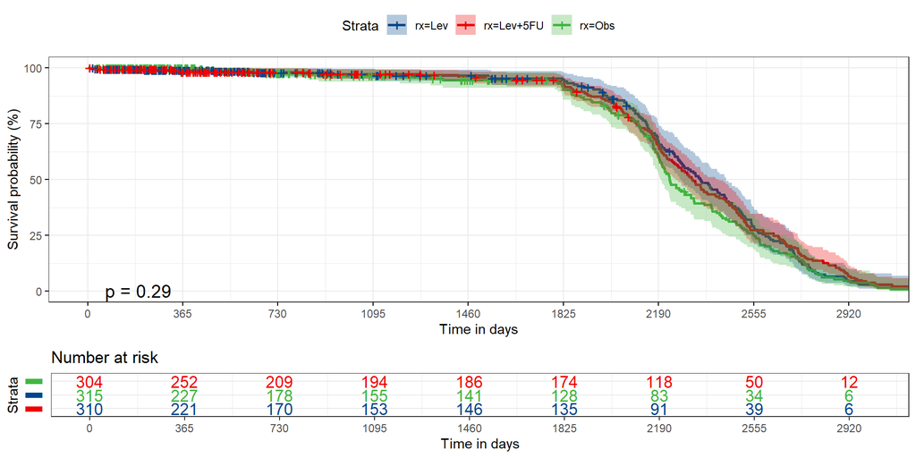

## Comparing three survival curves

```r
survdiff(col_432$S ~ col_432$rx)
```

```
Call:
survdiff(formula = col_432$S ~ col_432$rx)

                     N Observed Expected (O-E)^2/E (O-E)^2/V
col_432$rx=Obs     315      138      123     1.797     2.479
col_432$rx=Lev     310      138      144     0.247     0.364
col_432$rx=Lev+5FU 304      185      194     0.410     0.717

 Chisq= 2.5  on 2 degrees of freedom, p= 0.3
```

This is the `rho = 0` result: the Mantel-Haenszel test.

## Emphasizing left-hand-side of curves

```r
survdiff(col_432$S ~ col_432$rx, rho = 1)
```

```
Call:
survdiff(formula = col_432$S ~ col_432$rx, rho = 1)

                     N Observed Expected (O-E)^2/E (O-E)^2/V
col_432$rx=Obs     315     75.9     67.0     1.205     2.445
col_432$rx=Lev     310     68.0     73.9     0.466     0.999
col_432$rx=Lev+5FU 304     92.4     95.5     0.101     0.253

 Chisq= 2.6  on 2 degrees of freedom, p= 0.3
```

This is the `rho = 1` result: the Peto and Peto modification of the Gehan-Wilcoxon test.

## Emphasizing the right-hand-side

```r
survdiff(col_432$S ~ col_432$rx, rho = -1)
```

```
Call:
survdiff(formula = col_432$S ~ col_432$rx, rho = -1)

                     N Observed Expected (O-E)^2/E (O-E)^2/V
col_432$rx=Obs     315      578      465      27.9     2.416
col_432$rx=Lev     310     1221     1449      35.8     2.973
col_432$rx=Lev+5FU 304     1195     1082      12.0     0.693

 Chisq= 4.5  on 2 degrees of freedom, p= 0.1
```

## Plotting the Cumulative Event Rate

Add `fun = "event"` to the plot…

```r
ggsurvplot(km_col_rx,
           data = col_432,
           fun = "event",
           ggtheme = theme_bw(),
           palette = "lancet",
           xlab = "Time in days",
           break.time.by = 365,
           conf.int = TRUE)
```

## Plotting the Cumulative Event Rate

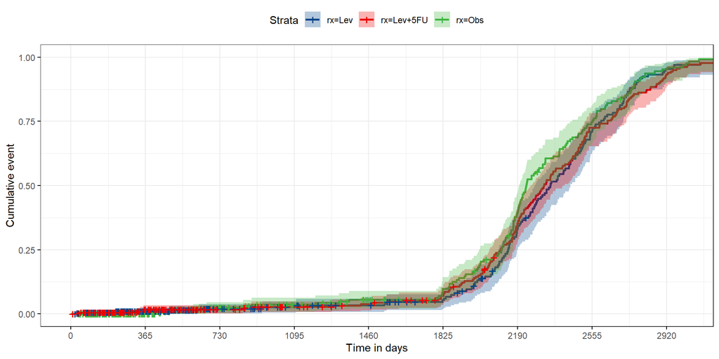

## Cumulative Hazard Function

Add `fun = "cumhaz"` to the plot (f(y) = -log(y))

```r
ggsurvplot(km_col_rx,
           data = col_432,
           fun = "cumhaz",
           ggtheme = theme_bw(),
           palette = "lancet",
           xlab = "Time in days",
           break.time.by = 365,
           conf.int = TRUE)
```

## Cumulative Hazard Function

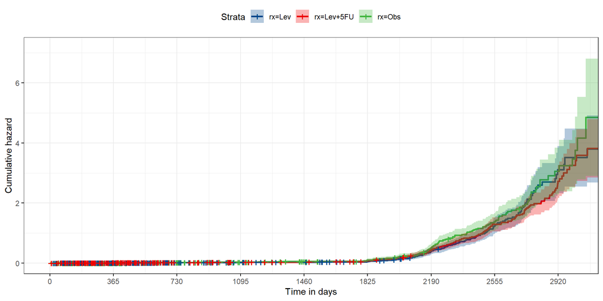

## Cox Regression Model

This is a Cox proportional hazards regression model.

```r
fit <- coxph( Surv(time, status == 0) ~ rx, data = col_432)
fit
```

```
Call:
coxph(formula = Surv(time, status == 0) ~ rx, data = col_432)

             coef exp(coef) se(coef)      z     p
rxLev     -0.1587    0.8533   0.1212 -1.310 0.190
rxLev+5FU -0.1635    0.8492   0.1130 -1.447 0.148

Likelihood ratio test=2.44  on 2 df, p=0.2947
n= 929, number of events= 461
```

- The key coefficients are the exponentiated ones, which describe relative hazards (hazard ratios.)

## Hazard Ratios and the Cox Model

A hazard ratio compares the rate at which our event (like death, or recurrence) occurs in one group compared to another group over time, essentially indicating the relative risk of the event happening in one group compared to another.

- A hazard ratio of 1 indicates no difference between the groups
- A hazard ratio > 1 indicates a higher risk in the named group as compared to the baseline.
- A hazard ratio < 1 indicates a lower risk in the named group as compared to the baseline.

## The `fit` model

- Our model `fit` looks at the impact of three treatments, with Observation as the baseline treatment, on days until recurrence.

```r
exp(fit$coefficients)
```

```
    rxLev rxLev+5FU
0.8532688 0.8492052
```

## Interpreting our `fit` (1/2)

- Note that we’re looking at the exponentiated coefficients here in order to describe relative hazards (hazard ratios.)

```r
model_parameters(fit, exponentiate = TRUE, pretty_names = FALSE,
                 ci = 0.90, digits = 3)
```

```
Parameter | Coefficient |    SE |         90% CI |      z |     p
-----------------------------------------------------------------
rxLev     |       0.853 | 0.103 | [0.699, 1.041] | -1.310 | 0.190
rxLev+5FU |       0.849 | 0.096 | [0.705, 1.023] | -1.447 | 0.148
```

The `fit` model estimates the hazard ratio for `rxLev` to be 0.853, with 90% CI (0.699, 1.041) which implies that the hazard of recurrence for a subject receiving Levamisole is estimated to be 85.3% as large as the hazard of recurrence for a subject who received Observation.

## Interpreting our `fit` (2/2)

```r
model_parameters(fit, exponentiate = TRUE, pretty_names = FALSE,
                 ci = 0.90, digits = 3)
```

```
Parameter | Coefficient |    SE |         90% CI |      z |     p
-----------------------------------------------------------------
rxLev     |       0.853 | 0.103 | [0.699, 1.041] | -1.310 | 0.190
rxLev+5FU |       0.849 | 0.096 | [0.705, 1.023] | -1.447 | 0.148
```

The `fit` model estimates the hazard ratio for `rxLev+5FU` to be 0.849, with 90% CI (0.705, 1.023) which implies that the hazard of recurrence for a subject receiving Levamisole and 5-FU is estimated to be 84.9% as large as the hazard of recurrence for a subject who received Observation.

- A forest plot can be used to graph this result nicely. (See next slide.)

## Forest Plot for Cox model

```r
ggforest(fit, data = col_432)
```

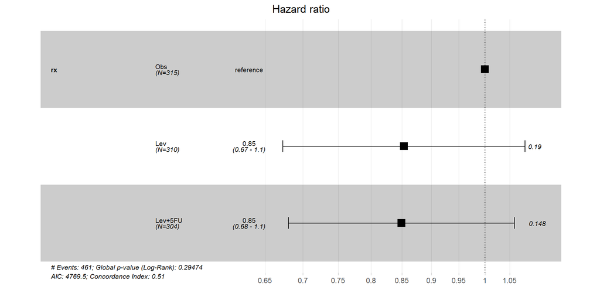

## Model Performance for `fit`

```r
model_performance(fit)
```

```
Response residuals not available to calculate mean square error. (R)MSE
  is probably not reliable.
```

```
# Indices of model performance

AIC      |     AICc |      BIC | Nagelkerke's R2 |  RMSE | Sigma
----------------------------------------------------------------
4769.501 | 4769.514 | 4779.169 |           0.003 | 0.699 | 0.000
```

## More on Cox Models

Coming in Classes 22 and 23…

### Save our tibble to an R data set

```r
write_rds(col_432, here("c16/data/col_432.Rds"))
```

I’ve placed these data on [our 432 data page](https://github.com/THOMASELOVE/432-data).

432 Class 16 | 2025-03-06 | https://thomaselove.github.io/432-2025/